# Economic Data 2026 - Labs

Week 2

**Aims:** Familiarise yourself with Eurostat, opening datasets in RStudio, manipulating dataframes, cleaning data.

Your country depends on the timing of your lab session:

- Group 1: Monday: Norway
- Group 2: Tuesday: Germany
- Group 3: Wednesday: Spain
- Group 4: Thursday: France

# Part 1

The data you worked on last week was from the Madison dataset, a collection of harmonized historical GDP and population data for various countries. The file `intro_R.R` will be useful for this exercise.

- Open an R script and save it as `lab_2.R`. Solve the exercises below in the script. **Hint**: Use `#` to write comments.
- Download the full Madison dataset, which is available [here](https://www.rug.nl/ggdc/historicaldevelopment/maddison/releases/maddison-project-database-2020?lang=en) in Excel format and store it on your computer.
- Have a look at the dataset in Excel. How many sheets are there?
- Import the sheet containing information on GDP per capita into RStudio. **Hint**: Click **Import Dataset > From Excel**, use **Browse** to locate the file, then click **Import**. Do you need to skip a line?
- Assign the dataframe the name `df`.
- Run the command `df[df$year>=1980,]`. How do you interpret the output? **Hint**: Run the command `df$year>=1980`. What does it do?
- Create a new dataframe that contains only observations after 1980.
- Create a new dataframe that contains only data for your assigned country. **Hint**: This code is almost correct `df<-df[,c('year', 'GBR')]`.
- Plot the data for the years 1980 to 2018 for your country. Include informative axis labels and a title. **Hint**: See the file `lab_1.R` in the folder for last week on Blackboard.

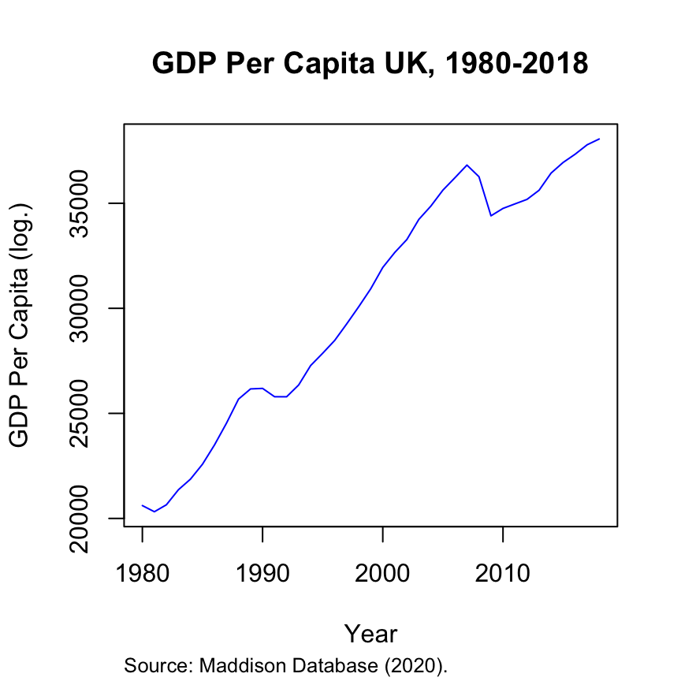

# Part 2

- Go to https://ec.europa.eu/eurostat/en/ and try to download data on the total population for as many years as possible. **Hint**: Database/detailed datasets/population and social conditions/demography population stock and balance/population (national level). Then click on the square (databrowser).
- Make the relevant selections on the website. Load the dataset into RStudio. **Hint**: total population, not by gender or age. Only for your country. Download in csv format.
- Keep only the columns in the dataframe containing the year and total population.
- Create a version of the plot below. Write a few sentences in your script about how the population of your assigned country has changed over time.
- Download data on deaths, births, emigration, and immigration for your country between 2010 and 2015.
- Load the datasets into RStudio.
- Create the table below. **Hint**: Adapt the code in `table_example.R` available on Blackboard. Use the accounting identity from this week’s lecture to calculate the statistical adjustment.
- (Difficult) Calculate the old age dependency ratio. How has it evolved? In light of your findings, how do you think the crude mortality rate has evolved? How about the crude birth rate? Discuss by writing a comment in your script. **Hint**: Look up the definition of the old age dependency ratio in the metadata. Use the command `aggregate(OBS_VALUE ~ TIME_PERIOD, data = older_65, sum)`.

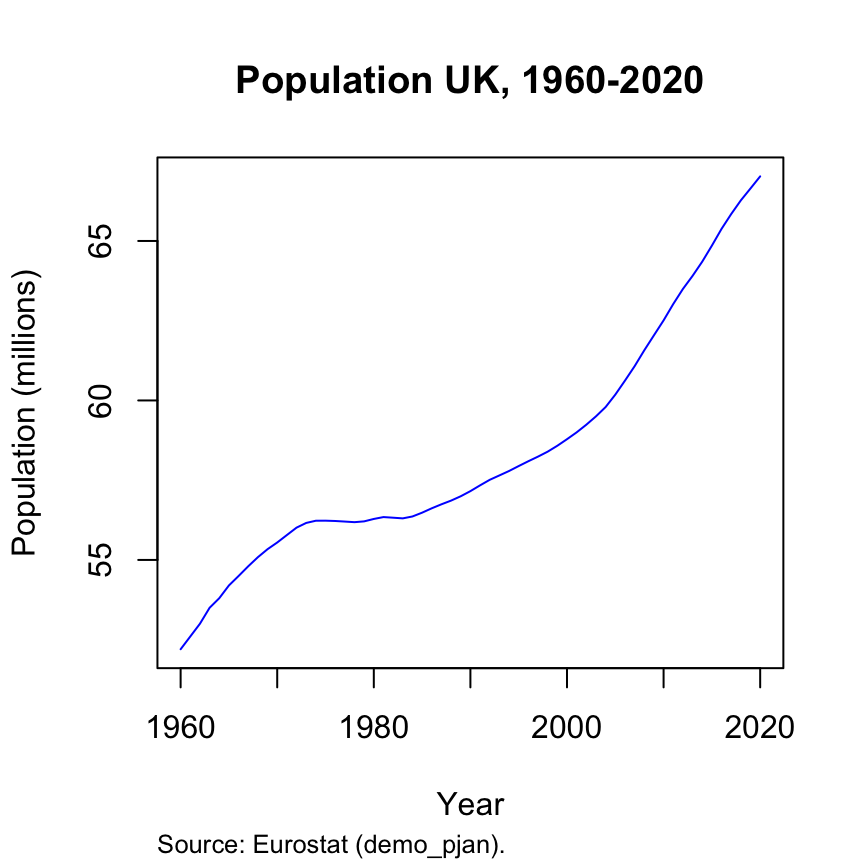

```
## Table: Decomposing population changes in the UK 2010 to 2015
## ----------------------------------------------------------------
## Population on January 1, 2010            62,510,197
##
## Live births                               3,982,283
## Deaths                                    2,826,707
## Natural change                            1,155,576
##
## Immigration                               2,813,071
## Emigration                                1,647,246
## Net migration                             1,165,825
##
## Natural change + Net migration            2,321,401
## Statistical discrepancy                      21,795
##
## Population on January 1, 2015            64,853,393
## ----------------------------------------------------------------
## Data source: Eurostat
```